**Help/ User Guide**

**Background:**

This shiny App is developed to allow analysis of Road Safety Digital Breath Test Data from England and Wales for year 2014. This Shiny App allows dynamic selection of data columns/features from the target dataset. Selected data columns/features will be dynamically summarized in the backend server and result visually presented back at the front end dashboard.

**User Interface**

Different areas of the Shiny App:

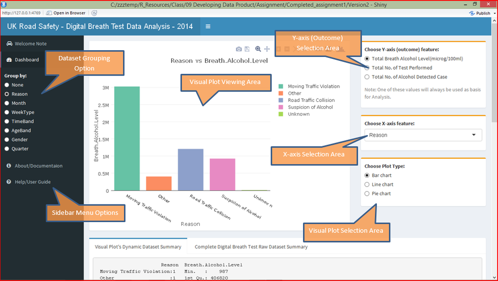

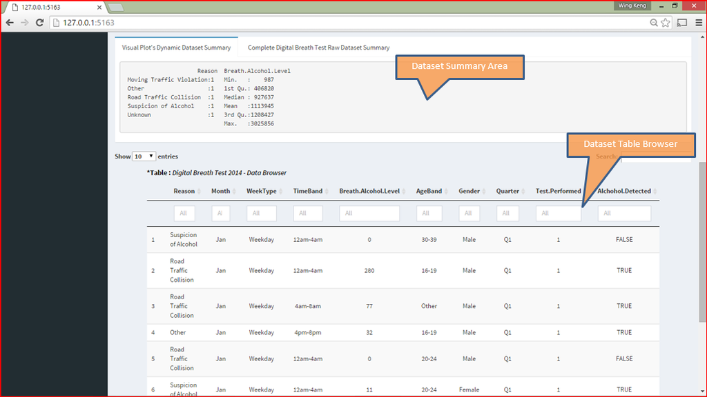

**Description/ Purposes**

Ability to switch between:

1. **Welcome Note** – A welcome message and basic information.
2. **Dashboard** - The Main App section :-
   1. Visual Plot Viewing Area (Interactive Data Presentation in Visual Mode)
   2. Data Columns/Features Selection Area (Y-axis, X-axis Data Column Selection)
   3. Dataset Grouping Options (Grouping of records)
   4. Dataset Summary Area (Visual Plot’s Dynamic Dataset Summary, Complete Digital Breath Test Raw Dataset Summary)
   5. Visual Plot Selection Area (Bar, Line or Pie Chart viewing)
   6. Dataset Table Browser ( Interactive Data records viewing from dataset)
3. **About/Document** -
   1. Background information about the App.
   2. Dataset Columns/Features Description
4. **Help/User Guide** – this page on simple user guide and FAQ.

**FAQ/ How to…**

**Filtering on the Legend**

[output not shown]

**Zooming View into the Dataset**

| **Q:** | How can I zoom in to review onto a smaller section of the Visual Plot/Graph? |
| --- | --- |
| **A:** | Option 1: Place mouse cursor on top right corner of Graph, shows the hidden Plotly function options. Use the “zoom” or “zoom in” functionality. |
|  | Option 2: Place mouse cursor on Graph area of interest. Click and drag a window selection area to zoom in. |

**Using the Data Table Browser**

| **Q:** | How can I make use of the Data Table Browser? |
| --- | --- |
| **A:** | You can either make use of the Generic Search String input box (top right corner of the Table Browser Area), or |
|  | Use the filtering input box on top of each columns to do record searching/filtering. |

**Data Table Browser showing all record rows from the Raw Dataset**

[output not shown]

**X-axis selection are specially filtered depending on Visual Plot Type Selection**

[output not shown]

**“Group by” options are specially filtered depending on Visual Plot Type Selection**

[output not shown]